# Entrega 1: Genetic Aassociation Studies

Big Data en Biociències

Francesc Aguirre, 1398024

Desembre de 2020

# 1. Anàlisi de dades GAS amb R

## 1.1 Obtenció de les dades i paquets

```r
library(SNPassoc)
library(magrittr)

library(rvest)
library(stringr)
```

```r
setwd("..")
root_path = getwd()

asthma <- read.table(paste0(root_path, "/data/asthma.txt"), header=TRUE)
source(paste0(root_path, "/code/GEA.R"))
```

S’utilitzarà el paquet estadístic **SNPassoc** per facilitar l’anàlisi dels SNPs, i el paquet **magrittr** per la creació de pipelines. També s’utilitzen algunes funcions de **purrr** per aplicar funcions similars a apply. Els paquets **rvest** i **stringr** s’han utilitzat per l’exercici personal opcional de web scrapping.

S’han utilitzat les dades d’un estudi epidemiologic sobre l’asma, que conté 1578 individus agrupats en casos i controls. Es tenen 51 SNPs, a més del país, sexe, edat, bmi i nivell d’obstrucció pulmonar.

## 1.2 Control de qualitat

### 1.2.1 Data Cleaning

S’eliminaran tots els SNPs en els que s’ha perdut el valor en més de 5% d’individus.

Codi (Annex: 1.2.1)

```r
# Funció: Elimina els SNPs que superen cert percentatge d'NA
args(remove_NA)
```

```
## function (data, maxPerc = 1)
## NULL
```

### 1.2.2 HWE Control

Codi (Annex: 1.2.2)

```r
# Funció: Elimina els SNPs que no compleixen les condicions de HWE sobre la distribucio dels controls
args(remove_HWE)
```

```
## function (data, strat_name, reflevel = 2, signif = 0.05)
## NULL
```

### 1.2.3 Aplicant pipeline

S’apliquen les transformacions anteriors en ordre. Primer transformem les dades en classe **snp**, tot seguit eliminem els SNPs amb NAs superiors al 5%, i finalment eliminem SNPs que no compleixin el test de HWE, estratificant per controls.

```r
first_col_SNP <- 7

dat <- asthma %>%
  setupSNP(colSNPs = first_col_SNP:ncol(asthma), sep = "/") %>%
  remove_NA(maxPerc = 5) %>%
  remove_HWE(strat_name = "caco", reflevel = "0")

snp_names <- names(dat)[first_col_SNP:ncol(dat)]
dim(dat)
```

```
## [1] 1578   49
```

S’han eliminat 8 SNPs que no complien les condicions de qualitat.

## 1.3 Selecció de variables no genètiques

```r
mod <- glm(caco ~ country + gender + age + bmi, family = binomial, data = dat)
round(summary(mod)$coef, 3)
```

```
##                    Estimate Std. Error z value Pr(>|z|)
## (Intercept)          -0.265      0.565  -0.469    0.639
## countryBelgium       16.152    406.054   0.040    0.968
## countryEstonia       16.151    650.235   0.025    0.980
## countryFrance        -1.193      0.291  -4.106    0.000
## countryGermany       -2.658      0.493  -5.389    0.000
## countryNorway        -2.146      0.393  -5.463    0.000
## countrySpain         -1.307      0.244  -5.355    0.000
## countrySweden         0.137      0.229   0.598    0.550
## countrySwitzerland   -0.237      0.301  -0.788    0.431
## countryUK             0.469      0.266   1.761    0.078
## genderMales          -0.379      0.137  -2.757    0.006
## age                  -0.033      0.010  -3.349    0.001
## bmi                   0.044      0.015   2.868    0.004
```

Veiem que totes les variables són significatives, i hi ha països que disminueixen les odds de tenir asma en referència a austràlia, i d’altres que no. Això ens diu, que ajustar els nostres models d’associació per aquestes variables pot ser encertat, per tal de disminuir el biaix quan es conclou que un SNP és significatiu.

## 1.4 Models d’associació genètica

### 1.4.1 Calculant els models

Per cada SNP, es crearan 3 models logistics: Dominant, Recessiu i log-Aditiu. Es seleccionarà el model amb el p-valor més baix dels 3.

Codi (Annex: 1.4.1)

```r
# Funció que crea els models logistics per un SNP i extrau la informació del model mes significatiu.
args(associationOut)
```

```
## function (base_formula, snpID, data, ajust = TRUE)
## NULL
```

```r
taula_resultats <- snp_names %>%
  lapply(associationOut, base_formula = "caco ~ country + gender + age + bmi",
         data = dat) %>%
  do.call(what = rbind)

taula_resultats$P_value_adj <- p.adjust(taula_resultats$P_value, method = "BH")
```

Ja tenim la taula amb els p-valors ajustats!

### 1.4.2 Busqueda del gen de l’SNP

Per fer l’anàlisi de xarxes de gens, s’ha de saber de quin gens provenen els SNPs més significatius. També és útil saber en quin cromosoma i posició estan si volem dibuixar un manhattan plot en una secció especifica.

Tenim diferents opcions per obtenir aquesta informació:

1. Anar a [dbSNP](https://www.ncbi.nlm.nih.gov/snp/) i buscar aquesta informació manualment. És viable quan tenim una quantitat de SNPs significatius petita, com és el nostre cás.
2. Utilitzar **web scrapping**. Anar a una web i extreure la informació que volem manualment, pot ser un procés repetitiu. Programar pot servir per automatitzar aquests processos.
3. Busqueda directa a partir d’una base de dades que ja contingui aquesta informació. És una opció molt més ràpida que web scrapping, per quan tenim grans quantitats de dades (ej: Utilitzant SQL).

Ja que s’ha esmentat web scrapping com a opció, s’ha realitzat un exemple d’aquesta tècnica amb els SNPs del nostre anàlisi per il·lustrar aquest procés.

Utilitzar web scrapping en el meu ordinador personal tarda al voltant d’1s/busqueda. És més ràpid que fer-ho manualment, però tampoc és poden fer milers de busquedes sense gastar hores de capacitat computacional en un ordinador personal.

Codi (Annex: 1.4.2)

```r
source(paste0(root_path, "/code/webScrappingSNP.R"))

# Llegeix la web en format html, i selecciona taula d'informació que volem.
args(load_ncbi_datanode)
```

```
## function (snp)
## NULL
```

```r
# De la taula html carregada d'un snp, extreu el gen
args(extractGen)
```

```
## function (ncbi_datanode)
## NULL
```

```r
# De la taula html carregada, extreu el cromosoma i posició
args(extractCh)
```

```
## function (ncbi_datanode)
## NULL
```

```r
data_web <- lapply(snp_names, function(snp_name){
  datanode <- load_ncbi_datanode(snp_name)
  chromosoma = extractCh(datanode)
  data.frame(Gene = extractGen(datanode),
             Ch = chromosoma$ch,
             Pos = chromosoma$pos)
}) %>%
  do.call(what = rbind)
taula_resultats <- cbind(taula_resultats, data_web)
```

Podem veure que un dels SNPs no s’ha trobat, i particularment comença amb un prefix (hopo) diferent a la resta (rs).

### 1.4.3 Taula de resultats

Un cop creada la taula, es pot ordenar, arrodonir…

Codi (Annex: 1.4.3)

```r
# Arrodoneix els digits de les columnes que volem, i els transforma tipus char (per Xtable).
# També es pot ordenar una de les columnes a priori.
args(rounding_Xtable)
```

```
## function (data, digits, ordenar = NULL)
## NULL
```

Taula 1: Per cada SNP tenim l’identificador, el model utilitzat (model amb menor p-valor), l’OR, el p-valor i el p-valor ajustat per la correcció de Benjamini-Hochberg. Finalment tenim informació sobre l’SNP en concret (gen, chromozoma, posició del cromozoma en milions de bases).

| ID | Model_type | OR | P_value | P_value_adj | Gene | Ch | Pos |
| --- | --- | --- | --- | --- | --- | --- | --- |
| rs184448 | Additiu | 1.45 | 0.000 | 0.014 | NPSR1 | 7 | 34.73 |
| rs324981 | Additiu | 0.72 | 0.001 | 0.024 | NPSR1 | 7 | 34.78 |
| rs324960 | Recessiu | 0.49 | 0.005 | 0.068 | NPSR1 | 7 | 34.76 |
| rs325462 | Additiu | 1.26 | 0.020 | 0.210 | NPSR1 | 7 | 34.81 |
| rs2303063 | Recessiu | 0.69 | 0.028 | 0.238 | SPINK5 | 5 | 148.10 |
| rs324396 | Dominant | 1.32 | 0.046 | 0.290 | NPSR1 | 7 | 34.75 |
| rs1422993 | Dominant | 1.31 | 0.047 | 0.290 | SPINK5 | 5 | 148.12 |
| rs10486657 | Dominant | 0.78 | 0.087 | 0.440 | NPSR1 | 7 | 34.76 |
| rs6084432 | Additiu | 1.24 | 0.097 | 0.440 | GFRA4 | 20 | 3.66 |
| rs1419780 | Dominant | 0.79 | 0.102 | 0.440 | NPSR1 | 7 | 34.78 |
| rs727162 | Dominant | 1.25 | 0.114 | 0.445 | NPSR1 | 7 | 34.83 |
| hopo546333 | Additiu | 0.74 | 0.141 | 0.504 |  |  | NA |
| rs3829366 | Dominant | 1.22 | 0.191 | 0.583 | PHF11 | 13 | 49.53 |
| rs1430094 | Dominant | 1.19 | 0.217 | 0.583 |  | 2 | 114.44 |
| rs898070 | Recessiu | 1.26 | 0.219 | 0.583 | NPSR1 | 7 | 34.66 |
| rs3756688 | Recessiu | 0.78 | 0.223 | 0.583 | SPINK5 | 5 | 148.06 |
| rs714588 | Dominant | 1.19 | 0.260 | 0.583 | NPSR1-AS1 | 7 | 34.65 |
| rs512625 | Dominant | 0.86 | 0.278 | 0.583 | ADAM33 | 20 | 3.67 |
| rs2853215 | Additiu | 1.12 | 0.291 | 0.583 |  | 20 | 3.69 |
| rs10238983 | Recessiu | 1.36 | 0.299 | 0.583 | NPSR1 | 7 | 34.86 |
| rs8000149 | Dominant | 1.15 | 0.308 | 0.583 | PHF11 | 13 | 49.52 |
| rs1367179 | Recessiu | 1.43 | 0.314 | 0.583 |  | 2 | 114.42 |
| rs2031532 | Additiu | 1.11 | 0.322 | 0.583 | PHF11 | 13 | 49.51 |
| rs11123242 | Recessiu | 1.43 | 0.329 | 0.583 |  | 2 | 114.42 |
| rs7332573 | Additiu | 1.16 | 0.377 | 0.583 | PHF11 | 13 | 49.52 |
| rs10250709 | Dominant | 0.89 | 0.390 | 0.583 | NPSR1 | 7 | 34.85 |
| rs1430093 | Dominant | 1.13 | 0.396 | 0.583 | DPP10 | 2 | 114.45 |
| rs13014858 | Dominant | 1.13 | 0.398 | 0.583 |  | 2 | 114.44 |
| rs4490198 | Dominant | 1.13 | 0.405 | 0.583 |  | 2 | 114.41 |
| rs2400478 | Recessiu | 0.85 | 0.412 | 0.583 | SPINK5 | 5 | 148.13 |
| rs3918395 | Dominant | 1.14 | 0.420 | 0.583 | ADAM33 | 20 | 3.67 |
| rs1023555 | Dominant | 1.11 | 0.443 | 0.595 | NPSR1 | 7 | 34.66 |
| rs10496465 | Recessiu | 1.47 | 0.465 | 0.606 | DPP10 | 2 | 114.50 |
| rs6958905 | Dominant | 0.91 | 0.500 | 0.632 | NPSR1 | 7 | 34.85 |
| rs963218 | Recessiu | 1.10 | 0.546 | 0.670 | NPSR1 | 7 | 34.67 |
| rs1419835 | Dominant | 1.07 | 0.647 | 0.773 | NPSR1 | 7 | 34.68 |
| rs746710 | Additiu | 1.03 | 0.740 | 0.849 | DPP10 | 2 | 114.45 |
| rs6737251 | Recessiu | 1.06 | 0.790 | 0.849 | DPP10 | 2 | 114.46 |
| rs2274276 | Additiu | 1.02 | 0.813 | 0.849 | PHF11 | 13 | 49.52 |
| rs2247119 | Additiu | 0.98 | 0.813 | 0.849 | PHF11 | 13 | 49.51 |
| rs2787095 | Dominant | 1.03 | 0.819 | 0.849 | ADAM33 | 20 | 3.68 |
| rs1430097 | Recessiu | 0.96 | 0.829 | 0.849 | DPP10 | 2 | 114.48 |
| rs4849332 | Recessiu | 1.03 | 0.871 | 0.871 |  | 2 | 114.42 |

## 1.4.4 Gràfics

Farem un mini manhattan plot amb l’eina **LocusZoom**. Primer s’ha de guardar la taula en un fitxer.

```r
write.table(taula_resultats, "taulaORs.txt", quote = FALSE, row.names = FALSE)
```

Tot seguit s’anirà a [LocusZoom](http://locuszoom.org/genform.php?type=yourdata) per fer el plot. S’entra el fitxer .txt generat, la columna de p-valors ajustats, s’indica la columna amb els noms dels SNPs i el delimitador s’especifica per espais.

També s’ha d’indicar la regió. Gràcies a que s’ha extret l’informació de tots els gens a partir de web scrapping ho tenim força fàcil. Els p-valors ajustats significatius es troben en el cromosoma 7. La posició d’aquests és entre 34.6 i 35 milions de bases.

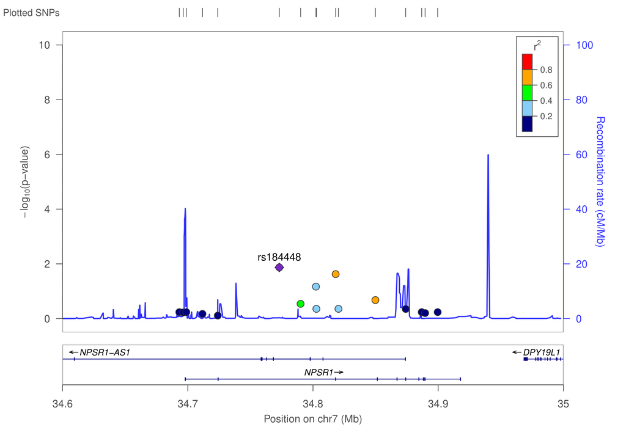

Gràfic 1

# 2. Interpretació de resultats

S’ha vist que els SNPs rs184448 i rs324981 són significatius en el model additiu, amb p-valors ajustats 0.014 i 0.024. L’SNP rs324960 en el model recessiu es podria arribar a tenir en compte tot i donar no significatiu al 0.05, amb p-valor de 0.068.

Els SNPs que han perdut la significació després de ser ajustats són el rs324960, rs325462, rs2303063, rs324396 i rs1422993. En alguns casos, el p-valor s’ha multiplicat per 10 a l’ajustar (ex: rs325462, p-val: 0.020, p-val_aj: 0.210).

Observant el manhattan plot en el Gràfic 1, podem veure que els 3 p-valors més significatius són propers entre ells, a una distància de menys de 0.07Mb, indicant que podríem estar veient una regió genètica amb influència sobre l’asma.

# ANNEX

### 1.2.1 Data Cleaning

### 1.2.2 HWE Control

## 1.4.1 Models d’associació

Crea data.frame amb l’output del model amb p-valor més petit.

## 1.4.2 Web Scrapping

Explicació funcions:

- **load_ncbi_datanode()**: Llegeix la pàgina web en format html, i agafa la taula que volem llegir.
- **extractGen()**: A partir de la taula que volem llegir, es mira quina fila coincideix amb la string “Gene”. S’agafa el primer valor corresponent. Per millorar-la en comptes d’agafar el primer valor es podria aplicar un str_remove(“[(Varview)]”) per eliminar el link, però de moment ja funciona con s’esperaria.
- **extractCh()**: Similar a extractGen() però amb la fila “Chromosome”. S’ha suposat que per exemple: 7:34733498 (GRCh38), està en el cromosoma 7, posició 34733498 en en genoma homosapiens GRCh38.

## 1.4.3 Taula models d’associació

Retoca la taula amb la informació dels models d’associació.

Executant xtable per la creació de la taula.